# Money in US Politics

Sebastian Kaltenbach

## Packages

In this assignment we will work with the following packages: tidyverse and scales (which you should be familiar with), and robotstxt and rvest for web scraping. We also use the dsbox package for pre-scraped data. You can load them with the following:

```r
library(tidyverse)
library(robotstxt)
library(rvest)
library(scales)
library(dsbox)
```

## Data collection via web scraping

The data come from OpenSecrets.org, a “website tracking the influence of money on U.S. politics, and how that money affects policy and citizens’ lives”. This website is hosted by The Center for Responsive Politics, which is a nonpartisan, independent nonprofit that “tracks money in U.S. politics and its effect on elections and public policy.” (Source)

Before getting started, let’s check that a bot has permissions to access pages on this domain. This function comes from the robotstxt package and it checks if a bot (or a web scraper like you!) has permissions to access the webpage. If the function returns TRUE, then the answer is “yes”, you’re technically allowed to scrape the webpage.

```r
paths_allowed("https://www.opensecrets.org")
```

```
 www.opensecrets.org
```

```
[1] TRUE
```

## Scraping 2020 contributons

Let’s begin by scraping the data for 2020 PAC contributions, one step at a time.

First, we define a new variable that stores the URL of the page we want to scrape data from as a character string:

```r
url_2020 <- "https://www.opensecrets.org/political-action-committees-pacs/foreign-connected-pacs/2020"
```

## Read the webpage

Next, we use the read_html() function to read the HTML data from the webpage:

```r
page <- read_html(url_2020)
```

## Bringing it all together

Now that we’ve planned which bits of the page we’re going to be scraping data from, it’s time to perform the scrape.

In order to convert data to a tibble, we’ll use the as_tibble() function from the tidyverse package. Fill in the blanks in the following code block to pick out the PAC contributions data.

```r
pac_2020 <- page %>%
  html_node(".DataTable-Partial") %>%
  html_table("td", header = TRUE, fill = TRUE) %>%
  as_tibble()
```

## Glimpse our new dataset

Great! Now that we’ve got our dataset on 2020 PAC contributions, let’s use the glimpse() function to take a look at it:

```r
glimpse(pac_2020)
```

```
Rows: 230
Columns: 5
$ `PAC Name (Affiliate)`             <chr> "7-Eleven", "ABB Group (ABB Group)", "Accenture (Accenture)", "Air Liquide Ame~
$ `Country of Origin/Parent Company` <chr> "Japan/Seven & I Holdings", "Switzerland/Asea Brown Boveri", "Ireland/Accentur~
$ Total                              <chr> "$20,000", "$16,900", "$83,500", "$37,800", "$182,000", "$94,750", "$71,300", ~
$ Dems                               <chr> "$1,000", "$6,800", "$50,500", "$15,800", "$79,000", "$30,750", "$36,150", "$0~
$ Repubs                             <chr> "$19,000", "$10,100", "$33,000", "$22,000", "$103,000", "$64,000", "$35,150", ~
```

## Clean up names

The names of the variables in the pac_2020 data frame are somewhat ill-formed. Rename the variables to the following: name, country_parent, total, dems, repubs. Note that dems is short for Democrats and repubs is short for Republicans, the two major parties in the US.

```r
pac_2020 <- pac_2020 %>%
  rename(
    name = `PAC Name (Affiliate)`,
    country_parent = `Country of Origin/Parent Company`,
    total = Total,
    dems = Dems,
    repubs = Repubs
  )
```

## Glimpse again

Let’s see how that looks now:

```r
glimpse(pac_2020)
```

```
Rows: 230
Columns: 5
$ name           <chr> "7-Eleven", "ABB Group (ABB Group)", "Accenture (Accenture)", "Air Liquide America", "Airbus Group~
$ country_parent <chr> "Japan/Seven & I Holdings", "Switzerland/Asea Brown Boveri", "Ireland/Accenture plc", "France/L'Ai~
$ total          <chr> "$20,000", "$16,900", "$83,500", "$37,800", "$182,000", "$94,750", "$71,300", "$2,000", "$336,500"~
$ dems           <chr> "$1,000", "$6,800", "$50,500", "$15,800", "$79,000", "$30,750", "$36,150", "$0", "$174,000", "$44,~
$ repubs         <chr> "$19,000", "$10,100", "$33,000", "$22,000", "$103,000", "$64,000", "$35,150", "$2,000", "$162,500"~
```

## Nearly there

That’s pretty good but the name variable looks pretty messy. There is lots of white space between the name and the affliate in parantheses. But remember, we have a string manipulation function that removes pesky white spaces: str_squish(). For the final data cleaning exercise (for now!), fix up the name variable using this function.

```r
pac_2020 <- pac_2020 %>%
  mutate(name = str_squish(name))
```

## One final glimpse

To finish of the scraping part of this tutorial, glimpse the data frame one more time to check everything looks good.

```r
glimpse(pac_2020)
```

```
Rows: 230
Columns: 5
$ name           <chr> "7-Eleven", "ABB Group (ABB Group)", "Accenture (Accenture)", "Air Liquide America", "Airbus Group~
$ country_parent <chr> "Japan/Seven & I Holdings", "Switzerland/Asea Brown Boveri", "Ireland/Accenture plc", "France/L'Ai~
$ total          <chr> "$20,000", "$16,900", "$83,500", "$37,800", "$182,000", "$94,750", "$71,300", "$2,000", "$336,500"~
$ dems           <chr> "$1,000", "$6,800", "$50,500", "$15,800", "$79,000", "$30,750", "$36,150", "$0", "$174,000", "$44,~
$ repubs         <chr> "$19,000", "$10,100", "$33,000", "$22,000", "$103,000", "$64,000", "$35,150", "$2,000", "$162,500"~
```

## Number of observations

```r
nrow(pac_2020)
```

```
[1] 230
```

## Number of variables

```r
ncol(pac_2020)
```

```
[1] 5
```

## Country and parent fields

First, let’s use the separate() function to separate country_parent into country and parent columns. Note that country and parent company names are separated by / (which we’ll need to specify) and also note that there are some entries where the / sign appears twice and in these cases we want to only split the value at the first occurrence of /.

This can be accomplished by setting the extra argument to “merge” so that the cell is split into only 2 segments, e.g. we want “Denmark/Novo Nordisk A/S” to be split into “Denmark” and “Novo Nordisk A/S”.

Fill the blanks in the following code block to do this.

```r
pac_all_raw <- pac_all_raw %>%
  separate(country_parent, into = c("country", "parent"), sep = "/", extra = "merge")
```

## Convert monetary values to numeric

Next, we want to convert the values of the total, dems and repubs fields to numerical values, which means removing the dollar signs at the start and the commas within the numbers.

To do this, there are a few functions that can help us: str_remove() and str_remove_all() can remove certain characters or patterns of characters from a string, and the as.numeric() function converts (or at least tries to convert) strings and other variable types into numeric values.

Since we have to apply this cleaning to all three fields, let’s write a function to do so. Remember that a function is just a packaged set of instructions (i.e. piece of code) that’s easy to reuse - without copying and pasting!

Let’s start building our function: we’ll call it parse_currency

```r
parse_currency <- function(x){
  x %>%
    str_remove("\\$") %>%
    str_remove_all(",") %>%
    as.numeric()
}
```

## Using the function

Now, we can combine the parse_currency() function with mutate() to apply it to the values in the data frame:

```r
pac_all <- pac_all_raw %>%
  mutate(
    total = parse_currency(total),
    dems = parse_currency(dems),
    repubs = parse_currency(repubs)
  )
```

## Glimpse the cleaned data

To top this off, let’s take a quick glimpse at the new dataset:

```r
glimpse(pac_all)
```

```
Rows: 2,156
Columns: 7
$ name    <chr> "7-Eleven", "ABB Group", "Accenture", "ACE INA", "Acuson Corp (Siemens AG)", "Adtranz (DaimlerChrysler)",~
$ country <chr> "Japan", "Switzerland", "Bermuda", "UK", "Germany", "Germany", "UK", "Netherlands", "UK", "France", "Fran~
$ parent  <chr> "Ito-Yokado", "Asea Brown Boveri", "Accenture plc", "ACE Group", "Siemens AG", "DaimlerChrysler AG", "Tat~
$ total   <dbl> 8500, 46000, 75984, 38500, 2000, 10500, 24000, 58250, 25000, 0, 21000, 2000, 11900, 41800, 17750, 14000, ~
$ dems    <dbl> 1500, 17000, 23000, 12500, 2000, 10000, 10000, 10500, 10000, 0, 6000, 1000, 6950, 6200, 1250, 4000, 5450,~
$ repubs  <dbl> 7000, 28500, 52984, 26000, 0, 500, 14000, 47750, 15000, 0, 15000, 1000, 4950, 35600, 16500, 10000, 14750,~
$ year    <dbl> 2000, 2000, 2000, 2000, 2000, 2000, 2000, 2000, 2000, 2000, 2000, 2000, 2000, 2000, 2000, 2000, 2000, 200~
```

## Data visualisation

First off in this section, we’re going to create a line plot of total contributions from all foreign-connected PACs in the UK and Canada over the years.

For this, we’re going to be following these steps: - Filter for only Canada and UK. - Calculate sum of total contributions from PACs for each year for each country by using a sequence of group_by() then summarise(). - Make a plot of total contributions (y-axis) by year (x-axis) where two lines identified by different colors represent each of Canada and UK.

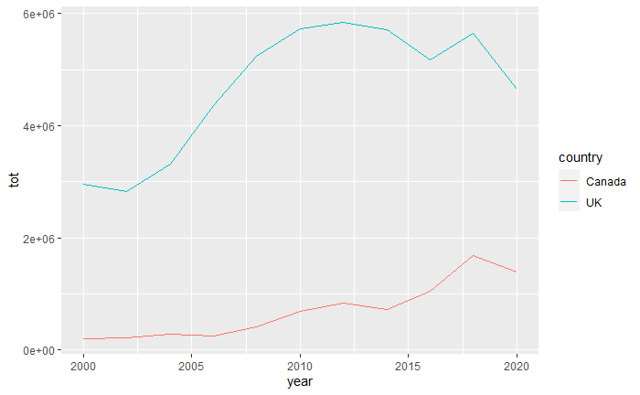

```r
pac_all %>%
  filter(country %in% c("Canada", "UK")) %>%
  group_by(country, year) %>%
  summarise(tot = sum(total), .groups = "drop") %>%
  ggplot(mapping = aes(x = year, y = tot, group = country, color = country)) +
  geom_line()
```

## Building a plot

### Step 1 - Filter

First, we need to filter the data for UK contributions:

```r
pac_all %>%
  filter(country == "UK")
```

| name | country | parent | total | dems | repubs | year |
| --- | --- | --- | --- | --- | --- | --- |
| ACE INA | UK | ACE Group | 38500 | 12500 | 26000 | 2000 |
| AE Staley Manufacturing (Tate & Lyle) | UK | Tate & Lyle | 24000 | 10000 | 14000 | 2000 |
| AIM Management Group | UK | AMVESCAP | 25000 | 10000 | 15000 | 2000 |
| Allied Domecq Spirits & Wine | UK | Allied Domecq | 41800 | 6200 | 35600 | 2000 |
| Anglogold Ltd | UK | Anglo American PLC | 14000 | 4000 | 10000 | 2000 |
| AstraZeneca Pharmaceuticals (AstraZeneca PLC) | UK | AstraZeneca | 131155 | 28250 | 102905 | 2000 |
| Atlantic Richfield (BP) | UK | BP PLC | 106454 | 30979 | 75475 | 2000 |
| Bacardi USA (Bacardi Ltd) | UK | Bacardi Ltd | 500 | 0 | 500 | 2000 |
| Bacardi USA (Bacardi Ltd) | UK | Bacardi Ltd | 0 | 0 | 0 | 2000 |
| BAE Systems North America (BAE Systems) | UK | BAE Systems | 243639 | 98580 | 145059 | 2000 |

[output cut: 497 more lines]

### Step 2 - Calculate total contributions

Next, we need to calculate total contributions to Democratic and Republican parties from all UK-connected PACs each year. This requires a group_by() and summarise() step:

```r
pac_all %>%
  filter(country == "UK") %>%
  group_by(year) %>%
  summarise(
    Democrat = sum(dems),
    Republican = sum(repubs),
    .groups = "drop"
  )
```

| year | Democrat | Republican |
| --- | --- | --- |
| 2000 | 952725 | 2004534 |
| 2002 | 951941 | 1880067 |
| 2004 | 1145177 | 2170154 |
| 2006 | 1440575 | 2872036 |
| 2008 | 2527063 | 2708656 |
| 2010 | 3044512 | 2631339 |
| 2012 | 2341463 | 3502718 |
| 2014 | 2296674 | 3398617 |
| 2016 | 1888931 | 3290098 |
| 2018 | 1965490 | 3673092 |

[output cut: 1 more lines]

### Step 3 - Pivoting

This results in a 11x3 tibble (11 years, and a column each for year, total contributions in that year to the Democratic party, and total contributions in that year to the Republican party). Ultimately we want to color the lines by party though, and this requires our data to be formatted a little differently: with two rows per year, one for contributions to the Democratic Party and the other for the Republican Party.

We can achieve this by pivoting our data to be longer (going from 11 to 22 rows)

```r
pac_all %>%
  filter(country == "UK") %>%
  group_by(year) %>%
  summarise(
    Democrat = sum(dems),
    Republican = sum(repubs),
    .groups = "drop"
  ) %>%
  pivot_longer(
    cols = c(Democrat, Republican),
    names_to = "party",
    values_to = "amount"
    )
```

| year | party | amount |
| --- | --- | --- |
| 2000 | Democrat | 952725 |
| 2000 | Republican | 2004534 |
| 2002 | Democrat | 951941 |
| 2002 | Republican | 1880067 |
| 2004 | Democrat | 1145177 |
| 2004 | Republican | 2170154 |
| 2006 | Democrat | 1440575 |
| 2006 | Republican | 2872036 |
| 2008 | Democrat | 2527063 |
| 2008 | Republican | 2708656 |

[output cut: 12 more lines]

Let’s save this as a new data frame to simplify the code for generating the plot:

```r
pac_all_final <- pac_all %>%
  filter(country == "UK") %>%
  group_by(year) %>%
  summarise(
    Democrat = sum(dems),
    Republican = sum(repubs),
    .groups = "drop"
  ) %>%
  pivot_longer(
    cols = c(Democrat, Republican),
    names_to = "party",
    values_to = "amount"
    )
```

### Step 4 - Plotting

Now we can form a basic plot of UK-based PAC contributions to each political party over time. Once we’ve done this, it’s not too hard to make it more aesthetically pleasing by adding further layers to ggplot.

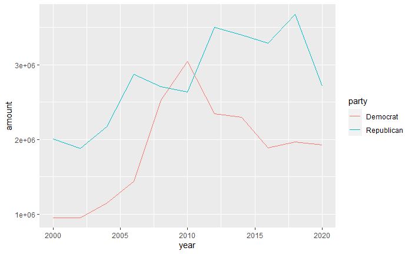

```r
pac_all_final %>%
  ggplot(mapping = aes(x = year, y = amount, color = party)) +
  geom_line()
```

### Step 4.1 - Changing party colours

Copy your code from the previous exercise, and add a scale_color_manual() line to the plot:

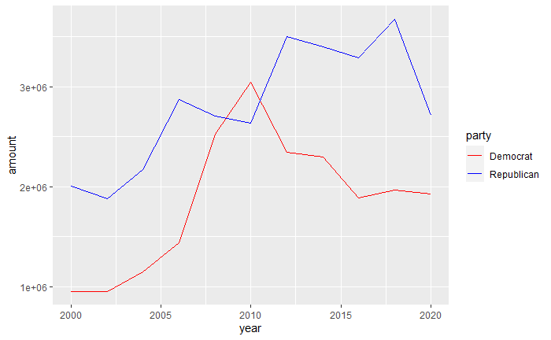

```r
pac_all_final %>%
  ggplot(mapping = aes(x = year, y = amount, color = party)) +
  geom_line() +
  scale_color_manual(values = c("red", "blue"))
```

### Step 4.2 - Dollar formatting

We can do this using the scale_y_continuous() function from the scales package. In this function, for the labels argument, the function of interest is label_dollar().

In the following code block, copy your code from the previous exercise and add another layer to reformat the dollar values. Fill in the blanks for the scale and suffix parameters. Refer to the Documentation if you need help.

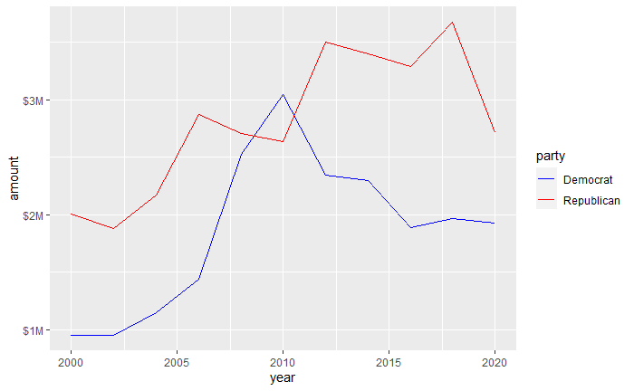

```r
pac_all_final %>%
  ggplot(mapping = aes(x = year, y = amount, color = party)) +
  geom_line() +
  scale_color_manual(values = c("blue", "red")) +
  scale_y_continuous(labels = label_dollar(scale = 0.000001, suffix = "M"))
```

### Step 4.3 - Descriptive labels

What plot would be complete without some proper labels, instead of the auto-generated ones?

Once again, copy your code from the previous exercise, and fill in the blanks so your plot shows the same labels as the plot we’re trying to recreate.

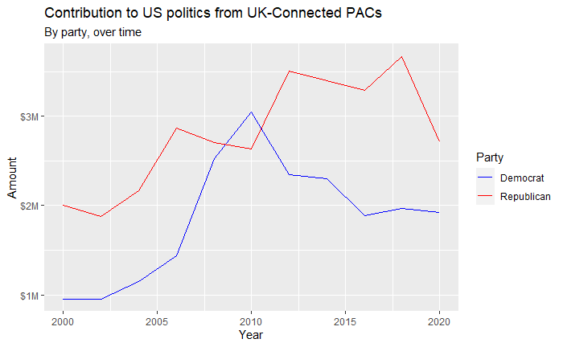

```r
pac_all_final %>%
  ggplot(mapping = aes(x = year, y = amount, color = party)) +
  geom_line() +
  scale_color_manual(values = c("blue", "red")) +
  scale_y_continuous(labels = label_dollar(scale = 0.000001, suffix = "M"))  +
  labs(
    x = "Year",
    y = "Amount",
    color = "Party",
    title = "Contribution to US politics from UK-Connected PACs",
    subtitle = "By party, over time"
  )
```

### Step 4.4 - theme_minimal()

For the final step, we apply the theme_minimal() layer to make certain aspects of the plot simpler or, well, minimalist.

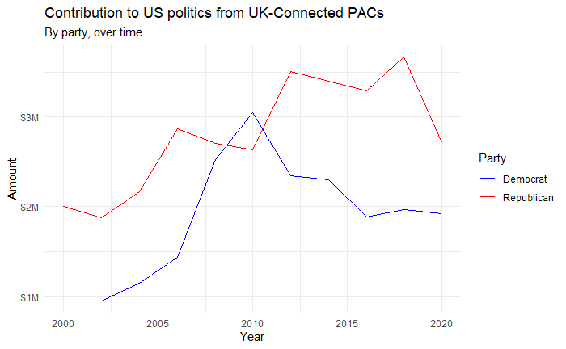

```r
pac_all_final %>%
  ggplot(mapping = aes(x = year, y = amount, color = party)) +
  geom_line() +
  scale_color_manual(values = c("blue", "red")) +
  scale_y_continuous(labels = label_dollar(scale = 0.000001, suffix = "M"))  +
  labs(
    x = "Year",
    y = "Amount",
    color = "Party",
    title = "Contribution to US politics from UK-Connected PACs",
    subtitle = "By party, over time"
  )  +
  theme_minimal()
```